# Pérdida de Cobertura Vegetal y su Efecto en la Degradación de Suelos en Zonas de Expansión Agrícola en el Departamento del Guaviare, Colombia (2015–2024)

Propuesta de Proyecto Final — Programación SIG

Autor/a

Santiago Gallego Soche

Fecha de publicación

4 de marzo de 2027

> **Área de estudio:** Departamento del Guaviare, Colombia  
> **Período de análisis:** 2015 – 2024  
> **Lenguajes de programación:** Python · Julia · R  
> **Asignatura:** Programación SIG

## 1 Título del Proyecto

**Pérdida de Cobertura Vegetal y su Efecto en la Degradación de Suelos en Zonas de Expansión Agrícola en el Departamento del Guaviare, Colombia (2015–2024): Un Enfoque Multilenguaje con Python, Julia y R.**

## 2 Introducción y Justificación

### 2.1 Definición del problema

El Guaviare constituye uno de los departamentos con mayor presión antrópica sobre la cobertura boscosa de la Amazonía colombiana. Según el Instituto de Hidrología, Meteorología y Estudios Ambientales (IDEAM, 2023), el departamento concentró aproximadamente el 12% de la deforestación nacional registrada entre 2016 y 2022, siendo la expansión de la frontera agrícola y la ganadería extensiva los principales motores de pérdida forestal. Esta dinámica no solo implica la eliminación de biomasa aérea y la liberación de carbono almacenado, sino que desencadena procesos de degradación edáfica que comprometen la productividad del suelo a largo plazo.

La conversión de bosque a uso agropecuario supone la ruptura de los ciclos biogeoquímicos que sostienen la estructura del suelo tropical. La eliminación de la cubierta vegetal reduce la materia orgánica, incrementa la erosión hídrica, altera la biota edáfica y disminuye la capacidad de retención hídrica (Cochrane y Barber 2009). Estos efectos se manifiestan espacialmente en la modificación de índices espectrales de vegetación y en el deterioro progresivo de las propiedades físico-químicas del suelo, lo que resulta en una pérdida permanente de la aptitud productiva en paisajes de alta fragilidad ecológica.

### 2.2 Relevancia espacial y justificación del enfoque SIG

El abordaje de esta problemática desde la geomática y la programación SIG es especialmente pertinente dado el carácter multitemporal, multifuente y multiescalar de los datos involucrados. La integración de imágenes satelitales de mediana y alta resolución (Landsat, Sentinel-2, MODIS), productos derivados de Google Earth Engine (GEE) y capas vectoriales de uso del suelo permite construir una narrativa espacial robusta que identifica no solo dónde ocurre la deforestación, sino cuáles son sus efectos sobre la calidad del suelo en el corto, mediano y largo plazo.

Desde el punto de vista profesional, el desarrollo de flujos de trabajo reproducibles en Python, Julia y R representa una contribución metodológica de alto valor para consultorías ambientales, entidades gubernamentales como el MADS, la UPRA y el IGAC, así como para proyectos de compensación de carbono bajo estándares REDD+ y Verra VCS. La combinación de teledetección, geoestadística y visualización avanzada en un mismo pipeline constituye una competencia diferencial en el mercado de la consultoría ambiental en Colombia.

## 3 Estado del Arte / Revisión Bibliográfica Preliminar

### 3.1 Monitoreo de deforestación con programación y SIG

La detección de cambios en cobertura boscosa mediante teledetección ha evolucionado significativamente con el acceso a plataformas de computación en la nube. Hansen et al. (2013) desarrollaron el primer mapa global de pérdida y ganancia forestal a 30 m de resolución usando Landsat, sentando las bases de los productos de cobertura que hoy sirven como referencia mundial. En Colombia, el IDEAM implementa el Sistema de Monitoreo de Bosques y Carbono (SMBYC) integrando estas metodologías con datos nacionales.

Desde el enfoque de programación, la API de Google Earth Engine en Python (Gorelick et al. 2017) ha democratizado el acceso a series temporales densas de imágenes satelitales. Trabajos recientes como los de Bullock, Woodcock, y Holden (2020) han demostrado la eficiencia de algoritmos de detección de rupturas temporales (e.g., CCDC, BFAST) aplicados sobre colecciones Landsat y Sentinel-2 para identificar eventos de deforestación con precisión subpíxel.

### 3.2 Degradación de suelos y teledetección

La estimación de la degradación del suelo a partir de índices espectrales ha sido ampliamente validada. El NDVI es el indicador más utilizado para aproximar la biomasa y la salud de la cobertura vegetal (Tucker 1979), mientras que índices como el BSI (*Bare Soil Index*) y el MSAVI han demostrado sensibilidad ante procesos de erosión y pérdida de materia orgánica (Escadafal 1994). Estudios en la Amazonia brasileña (Nepstad et al. 2008) correlacionaron la disminución sostenida del NDVI con la compactación del suelo y la reducción de la infiltración hídrica.

En Colombia, trabajos del CIAT han combinado datos de percepción remota con muestreos edáficos para construir modelos predictivos de degradación en zonas de frontera agrícola, destacando la necesidad de enfoques integrados que combinen múltiples fuentes de datos.

### 3.3 Uso de Julia en procesamiento geoespacial

Aunque Python y R dominan el ecosistema de la ciencia de datos geoespaciales, Julia ha emergido como una alternativa de alto rendimiento para el procesamiento de raster densos y series temporales. El paquete `Rasters.jl` permite manipular grandes colecciones de datos multidimensionales con sintaxis expresiva y velocidad de ejecución cercana a C. Su uso en detección de cambios y álgebra raster intensiva representa una ventaja computacional significativa frente a implementaciones equivalentes en Python puro.

## 4 Objetivos

### 4.1 Objetivo General

Analizar la relación espacio-temporal entre la pérdida de cobertura vegetal y la degradación de suelos en zonas de expansión agrícola del departamento del Guaviare, Colombia, durante el período 2015–2024, mediante el desarrollo de un flujo de trabajo reproducible e integrado en Python, Julia y R.

### 4.2 Objetivos Específicos

**OE1.** Cuantificar y cartografiar la pérdida de cobertura vegetal en el Guaviare entre 2015 y 2024 a partir de imágenes Landsat-8/9 y Sentinel-2, utilizando **Python** como lenguaje de descarga y preprocesamiento de datos en Google Earth Engine.

**OE2.** Detectar y caracterizar patrones de degradación del suelo mediante el análisis multitemporal de índices espectrales (NDVI, BSI, MSAVI, NBR) utilizando **Julia** para el procesamiento eficiente de series de tiempo raster y la identificación de puntos de ruptura.

**OE3.** Modelar espacialmente la relación entre la pérdida de cobertura y los indicadores de degradación edáfica mediante métodos geoestadísticos (kriging, semivariogramas) en **R**, y generar cartografía temática y visualizaciones analíticas como producto final del proyecto.

## 5 Área de Estudio

### 5.1 Delimitación geográfica

El territorio está conformado por tres grandes unidades fisiográficas: la llanura aluvial del río Guaviare y sus afluentes, las serranías del Chiribiquete y la Lindosa, y la zona de transición sabana-selva en el piedemonte oriental.

### 5.2 Mapa base del área de estudio

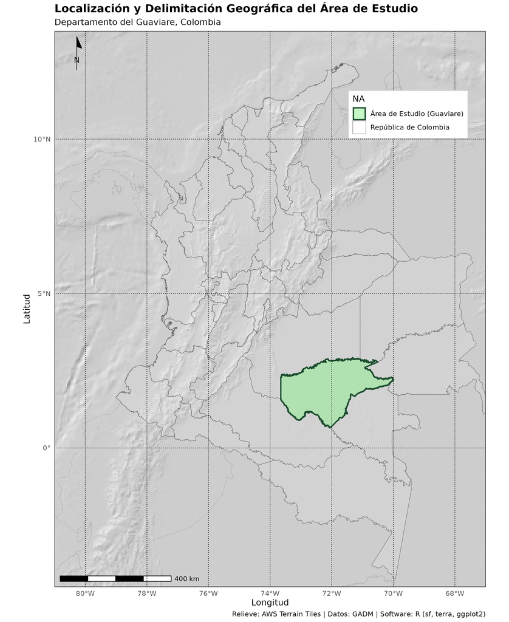

### 5.3 Contexto socioambiental

El Guaviare concentra una de las tasas de deforestación más altas de Colombia, impulsada principalmente por la ganadería extensiva, los cultivos ilícitos y la colonización espontánea post-acuerdo de paz. Los municipios de **San José del Guaviare**, **El Retorno** y **Calamar** son los de mayor presión antrópica sobre el bosque. La presencia del Parque Nacional Natural Serranía de Chiribiquete (Patrimonio de la Humanidad UNESCO) hace que la presión sobre las zonas de amortiguamiento sea especialmente relevante desde el punto de vista de la conservación.

## 6 Fuentes de Datos

Fuentes de datos utilizadas en el proyecto.

| Dataset / API | Fuente / Plataforma | Uso en el proyecto |
| --- | --- | --- |
| Landsat 8/9 SR (C2) | GEE / USGS | Índices espectrales multitemporales (NDVI, BSI, NBR) 2015–2024 |
| Sentinel-2 MSI L2A | GEE / ESA Copernicus | Series de tiempo de alta resolución (10 m) para detección de cambios 2017–2024 |
| MODIS Terra MOD13Q1 | GEE / NASA LP DAAC | NDVI/EVI cada 16 días a 250 m para tendencias de largo plazo |
| Hansen Global Forest Change v1.11 | GEE / UMD | Capas de pérdida forestal anual 2015–2023 como referencia de validación |
| SMBYC — Deforestación Colombia | IDEAM (Open Data) | Polígonos oficiales de deforestación por núcleos activos en el Guaviare |
| SoilGrids 2.0 (250 m) | ISRIC World Soil Information | Variables edáficas: SOC, textura, pH, BD — descarga vía API REST en Python |
| SRTM DEM / Copernicus DEM | NASA / ESA (GEE) | Modelo de elevación para análisis de pendientes y susceptibilidad erosiva |
| Límites político-administrativos | IGAC — Geovisor Colombia | Capa departamental y municipal para acotación del área de estudio |
| Catálogo de Ecosistemas 1:100.000 | MADS / IDEAM | Clasificación de ecosistemas terrestres como referencia de cobertura base |
| Datos climáticos ERA5 | ECMWF / GEE | Temperatura, precipitación como variables de contexto en el modelo espacial |

## 7 Metodología Propuesta

La metodología se estructura en tres fases secuenciales y complementarias, cada una asociada a un lenguaje de programación específico según sus fortalezas técnicas.

```
flowchart LR
    A["🐍 Python\nGEE API + rasterio"] --> B["📦 GeoTIFF Stacks\nNDVI · BSI · NBR · MSAVI"]
    B --> C["⚡ Julia\nRasters.jl + BFAST"]
    C --> D["📊 Slope Maps\nPuntos de ruptura · CSV"]
    D --> E["📈 R\nterra + gstat + tmap"]
    E --> F["🗺️ Productos finales\nKriging · Cartografía · Report"]

    style A fill:#1F4E79,color:#fff
    style C fill:#2E75B6,color:#fff
    style E fill:#107C10,color:#fff
    style B fill:#EBF3FB
    style D fill:#EBF3FB
    style F fill:#E8F5E9
```

### 7.1 Fase 1: Descarga y preprocesamiento de datos (Python)

Python actuará como el lenguaje de orquestación y acceso a datos. Se utilizará la API de Google Earth Engine (`earthengine-api`) para la extracción de colecciones de imágenes Landsat y Sentinel-2, aplicando filtros por fecha, cobertura de nubes y área de interés.

**Librerías principales:**

Tabla 1: Librerías Python utilizadas en la Fase 1

| Librería | Función |
| --- | --- |
| `earthengine-api` / `geemap` | Acceso y exportación desde GEE |
| `rasterio` | Lectura y escritura de rasters GeoTIFF |
| `geopandas` / `shapely` | Gestión de capas vectoriales |
| `requests` | Descarga API REST (SoilGrids) |
| `pandas` / `numpy` | Procesamiento tabular y numérico |
| `matplotlib` | Visualizaciones exploratorias |

**Ejemplo de código — Descarga de NDVI desde GEE:**

```python
import ee
import geemap

# Autenticación y inicialización
ee.Initialize()

# Área de interés: Guaviare
guaviare = ee.FeatureCollection("FAO/GAUL/2015/level1") \
             .filter(ee.Filter.eq("ADM1_NAME", "Guaviare"))

# Colección Landsat 8/9 con filtros
def calcular_ndvi(imagen):
    ndvi = imagen.normalizedDifference(["SR_B5", "SR_B4"]).rename("NDVI")
    return imagen.addBands(ndvi)

coleccion = (ee.ImageCollection("LANDSAT/LC08/C02/T1_L2")
    .filterBounds(guaviare.geometry())
    .filterDate("2015-01-01", "2024-12-31")
    .filter(ee.Filter.lt("CLOUD_COVER", 20))
    .map(calcular_ndvi))

# Exportar stack anual
for year in range(2015, 2025):
    img_anual = (coleccion
        .filterDate(f"{year}-01-01", f"{year}-12-31")
        .select("NDVI")
        .median()
        .clip(guaviare))

    task = ee.batch.Export.image.toDrive(
        image=img_anual,
        description=f"NDVI_Guaviare_{year}",
        scale=30,
        region=guaviare.geometry(),
        fileFormat="GeoTIFF"
    )
    task.start()
    print(f"Exportando NDVI {year}...")
```

### 7.2 Fase 2: Procesamiento de series temporales (Julia)

Julia se empleará para el procesamiento computacionalmente intensivo de los stacks raster. Se implementará un pipeline de análisis de series de tiempo usando `Rasters.jl` y `ArchGDAL.jl`. El algoritmo BFAST detectará puntos de ruptura en las series de NDVI, identificando momentos y ubicaciones de cambio abrupto asociados a eventos de deforestación.

**Librerías principales:**

Tabla 2: Librerías Julia utilizadas en la Fase 2

| Librería | Función |
| --- | --- |
| `Rasters.jl` | Carga y manipulación de rasters multidimensionales |
| `ArchGDAL.jl` | Interfaz GDAL para lectura/escritura |
| `DimensionalData.jl` | Arrays con dimensiones etiquetadas |
| `GLM.jl` | Regresión temporal píxel a píxel |
| `DataFrames.jl` | Procesamiento tabular |
| `Plots.jl` | Visualización de series de tiempo |

**Ejemplo de código — Análisis de tendencia temporal:**

```julia
using Rasters, ArchGDAL, Statistics, GLM, DataFrames

# Cargar stack de NDVI (10 bandas = 10 años)
ndvi_stack = Raster("data/NDVI_Guaviare_2015_2024.tif")

años = collect(2015:2024)

# Calcular pendiente de regresión lineal por píxel
function pendiente_temporal(serie)
    df = DataFrame(y = Float64.(serie), x = Float64.(años))
    modelo = lm(@formula(y ~ x), df)
    return coef(modelo)[2]  # slope
end

# Aplicar función al stack raster
slope_map = mapslices(pendiente_temporal, ndvi_stack, dims=Band)

# Guardar resultado
write("output/slope_NDVI_Guaviare.tif", slope_map)
println("✓ Mapa de tendencia exportado correctamente.")
```

**Productos generados:** mapas de ruptura temporal, slope maps, matrices de correlación píxel-variable.

### 7.3 Fase 3: Geoestadística y visualización (R)

R concentrará el análisis geoestadístico y la producción cartográfica final. Se utilizarán `terra` y `sf` para la gestión de datos espaciales, y `gstat` para el ajuste de semivariogramas y kriging ordinario.

**Librerías principales:**

Tabla 3: Librerías R utilizadas en la Fase 3

| Librería | Función |
| --- | --- |
| `terra` / `sf` | Gestión de datos raster y vectoriales |
| `gstat` | Semivariogramas y kriging |
| `tmap` | Cartografía estática e interactiva |
| `ggplot2` + `ggspatial` | Visualización y elementos cartográficos |
| `dplyr` / `tidyr` | Manipulación de datos |
| `rmarkdown` / `quarto` | Informe reproducible |

**Ejemplo de código — Semivariograma y kriging:**

```r
library(terra)
library(sf)
library(gstat)
library(tmap)

# Cargar raster de pendiente NDVI (desde Julia)
slope_r <- rast("output/slope_NDVI_Guaviare.tif")

# Convertir a puntos de muestreo
puntos <- as.data.frame(slope_r, xy = TRUE, na.rm = TRUE)
puntos_sf <- st_as_sf(puntos, coords = c("x", "y"), crs = 4326)

# Ajuste de semivariograma
vgm_emp <- variogram(slope_NDVI ~ 1, data = puntos_sf)
vgm_fit <- fit.variogram(vgm_emp, model = vgm("Sph"))

# Kriging ordinario
grid_guaviare <- st_make_grid(puntos_sf, cellsize = 0.01)
krige_result <- krige(slope_NDVI ~ 1,
                      locations = puntos_sf,
                      newdata = grid_guaviare,
                      model = vgm_fit)

# Visualización con tmap
tm_shape(krige_result) +
  tm_fill("var1.pred",
          palette = "-RdYlGn",
          title = "Tendencia NDVI\n(pendiente anual)") +
  tm_borders(alpha = 0.2) +
  tm_scale_bar(position = c("left", "bottom")) +
  tm_compass(position = c("right", "top")) +
  tm_layout(title = "Degradación de cobertura vegetal\nGuaviare 2015–2024",
            legend.outside = TRUE)
```

## 8 Referencias Bibliográficas

Bullock, Eric L., Curtis E. Woodcock, y Christopher E. Holden. 2020. «Improved classification and change detection techniques for mapping tropical forest disturbance using Landsat time series». *Remote Sensing of Environment* 238: 111176. https://doi.org/10.1016/j.rse.2019.111176.

Cochrane, Mark A., y Christopher P. Barber. 2009. «Climate change, human land use and future fires in the Amazon». *Global Change Biology* 15 (3): 601-12. https://doi.org/10.1111/j.1365-2486.2008.01786.x.

Escadafal, Richard. 1994. «Soil spectral properties and their relationships with environmental parameters – examples from arid regions». *Imaging Spectrometry – a Tool for Environmental Observations*, 71-87. https://doi.org/10.1007/978-94-011-1197-3_5.

Gorelick, Noel, Matt Hancher, Mike Dixon, Simon Ilyushchenko, David Thau, y Rebecca Moore. 2017. «Google Earth Engine: Planetary-scale geospatial analysis for everyone». *Remote Sensing of Environment* 202: 18-27. https://doi.org/10.1016/j.rse.2017.06.031.

Hansen, Matthew C., Peter V. Potapov, Rebecca Moore, Matt Hancher, S. A. Turubanova, Alexandra Tyukavina, David Thau, et al. 2013. «High-resolution global maps of 21st-century forest cover change». *Science* 342 (6160): 850-53. https://doi.org/10.1126/science.1244693.

Nepstad, Daniel C., Ingrid M. Tohver, David Ray, Paulo Moutinho, y Georgina Cardinot. 2008. «Mortality of large trees and lianas following experimental drought in an Amazon forest». *Ecology* 88 (9): 2259-69. https://doi.org/10.1890/06-1046.1.

Tucker, Compton J. 1979. «Red and photographic infrared linear combinations for monitoring vegetation». *Remote Sensing of Environment* 8 (2): 127-50. https://doi.org/10.1016/0034-4257(79)90013-0.